# Conclusions

## Synthesizing Results from Across the Project

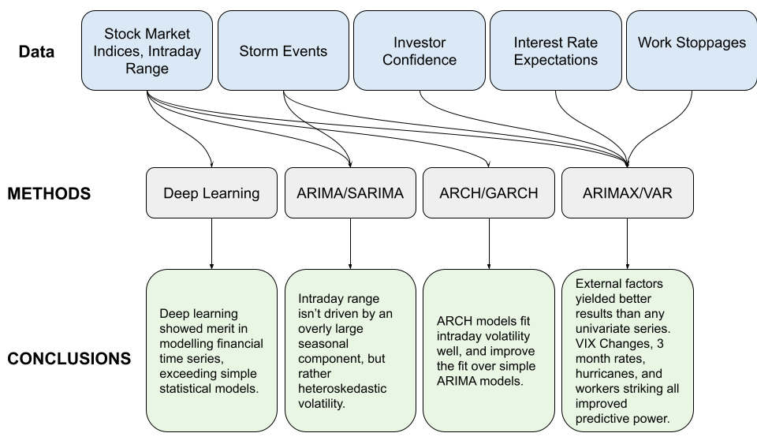

Results in Brief

The project attempted to model intraday volatility, measured as the range between the highest and lowest daily price recorded as a percentage of the opening price. In particular, it looked at this metric for popular exchange traded funds tracking the S&P 500, NASDAQ 100, and Russel 2000. To accomplish this, it introduced exogenous variables from four sources: extreme weather events, interest rate expectations, investor confidence, and labor stoppages.

Ultimately, the three ETFs proved to have similar dynamics both as univariate time series and also as elements in multivariate models. The external predictors, however, seemed substantially distinguished from eachother and almost all contained some relevant data in predicting the three outcome variables. When exploring the data, it became clear that the amount of variation in the indices intraday range was not constant, and at different points in time had been much higher or lower than average. Just as with the overall trend, however, the three indices shared this trait in common.

In an attempt to model these variables and make predictions, the project began with ARIMA and SARIMA models. ARMA models proved immediately effective, with all of the main series having a variant of an ARMA model performing well. Somewhat surprisingly, however, the financial instruments did not have major seasonal components. This rendered SARIMA models largely ineffective in describind their behavior.

The next step was to incorporate the exogenous datasets in order to explain more of the variation in the indices’ intraday ranges. These exogenous predictors were combined in a number of ways, through both VAR and ARIMAX models. On this front, the role of the exogenous predictors was encouraging. All four datasets had relevant predictive power. In particular: the daily change in the VIX (investor sentiment), hurricane events (weather data), daily striking workers (labor stoppages), and three month interest rate changes (bond yield data). While these models did not explain all of the variation in the data by any means, they demonstrated that these external factors impact market volatility.

Financial time series modeling with ARCH and GARCH models made intuitive sense for the data. The intraday ranges exhibited similar behavior to daily stock market returns, which are often the focus of ARCH and GARCH models. All of the major indices were well suited to GARCH models in some form, which suggests that volatility can be modeled similar to traditional financial metrics.

Finally, several deep learning methods, including RNN, GRU, and LSTM models, were applied to the dataset. Here, the LSTM models performed the best, and outperformed all traditional statistical models except for the VAR approaches. This demonstrated that univariate volatility is best understood with deep learning, although multivariate analysis is still best performed statistically.

Overall, the work in this project has indicated that many external factors play a role in shaping market volatility, and the results contained herein suggest future work is merited in identifying other exogenous predictors that are shaping the markets which impact all of our lives.

## Answering Research Questions

[output not shown]